# Recovery of tree community composition across different types of anthropogenic disturbances and characterization of their effect using Landsat time series in Bornean tropical montane forest - ScienceD

## Outline

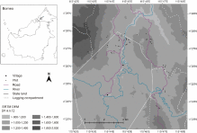

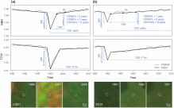

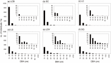

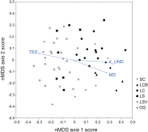

## Extras (1)

1. Supplementary material

## [Biological Conservation](https://www.sciencedirect.com/journal/biological-conservation)

[Volume 267](https://www.sciencedirect.com/journal/biological-conservation/vol/267/suppl/C), March 2022, 109489

# Recovery of tree community composition across different types of anthropogenic disturbances and characterization of their effect using Landsat time series in Bornean tropical montane forest

[KeikoIoki<sup>a</sup>](https://www.sciencedirect.com/science/article/abs/pii/S0006320722000428#!)[DanielJames<sup>b</sup>](https://www.sciencedirect.com/science/article/abs/pii/S0006320722000428#!)[Mui-HowPhua<sup>b</sup>](https://www.sciencedirect.com/science/article/abs/pii/S0006320722000428#!)[SatoshiTsuyuki<sup>c</sup>](https://www.sciencedirect.com/science/article/abs/pii/S0006320722000428#!)[NobuoImai<sup>d</sup>](https://www.sciencedirect.com/science/article/abs/pii/S0006320722000428#!)

## Highlights

**•**

We compared recovery in tropical montane forests after various types of land use.

**•**

Landsat time-series change metrics were used to assess effects of human disturbance.

**•**

Community composition was the most important indicator of forest recovery.

**•**

Derived change metrics corresponded to community composition (*R*<sup>2</sup> = 0.32–0.51).

## Abstract

Anthropogenic pressure in tropical [montane forests](https://www.sciencedirect.com/topics/agricultural-and-biological-sciences/montane-forests) is rapidly increasing, becoming a major threat to these complex ecosystems. Studies have shown that the wide variety of human activities in tropical uplands results in different ecological responses of [secondary forests](https://www.sciencedirect.com/topics/agricultural-and-biological-sciences/secondary-forests), but basic information on the disturbance impacts and underlying recovery processes is lacking. Here, we compared structural characteristics and tree community composition of [old growth forest](https://www.sciencedirect.com/topics/earth-and-planetary-sciences/old-growth-forest) and secondary forests in a montane region of Sabah, Malaysia, which experienced five different anthropogenic disturbances. We also investigated the use of metrics from spectral trajectories of a [Landsat](https://www.sciencedirect.com/topics/agricultural-and-biological-sciences/landsat) time series (LTS) change detection algorithm (LandTrendr) to identify characteristics of disturbance events and their linkage to the recovery of tree community composition, with field validation. Five LTS metrics—time since the greatest disturbance (TSD), magnitude of disturbance (MD), distance to undisturbed forests (d_UND), recovery indicator (RI), and years to recovery (Y2R) were derived and were related to field-based tree community composition. Our analysis revealed a gradient of recovery patterns in community composition and structural attributes among forest disturbance types, suggesting the importance of community composition as an indicator of forest recovery. Among derived LTS metrics, TSD, MD, d_UND, and Y2R 100% were significantly related with the similarity in community composition. Our results suggest that spectral trajectories from LTS can serve as a useful predictor of community composition change in recovering stands. This approach provides an efficient means for developing systematic conservation strategies for high-elevation regions in the tropics, where human-modified landscapes are expanding.

## Keywords

Land use

Forest succession

Biodiversity conservation

Borneo

LandTrendr

[View full text](https://www.sciencedirect.com/science/article/pii/S0006320722000428)

© 2022 Elsevier Ltd. All rights reserved.